Project 1 Report  
Class Name: ALY6010- Probability Theory and Introductory Statistics  
Name: Srishti Singh  
Instructor: Prof. Dee Chiluiza Reyes, PhD  
Date: 08 November, 2022

> **INTRODUCTION**

The most significant industry in the world, the automobile sector encompasses both passenger cars and commercial vehicles. It is predicted that global vehicle sales will drop to just about 70 million units in 2021 from 80 million units in the previous year. China is regarded as having the world’s largest market for vehicle sales and production (Wagner, 2021). In the case of the second wave of COVID 19, momentum in the automotive industry would be favorable, claims Tarun Garg. Analysts at IHS Markit, JATO Dynamics, Credit Suisse, and Nomura forecast that the global vehicle market would rise by 23% to 32% in 2021. The year 2010 saw the fastest growth recorded at 30%. **ref- (Thakkar, K., Shyam, A. R., Mukherjee, S., & Auto, 2021)**

**Discrete Probability Distribution :** Countable variables with a finite number of values are discrete variables (Bluman, 2018). The example includes discrete variables such as flower varieties, the number of children in a family, automobile colour, and car model. The probability distribution is always finite since there are only a finite number of possible outcomes for these variables.

**ANALYSIS SECTION**

**Task 1:** **Implementation of Select, T and describe functions to transform few of the variables in the dataset**

```r
# Task 1:
M1data_carsales%>%
   dplyr::select(Efficiency,Power_bhp, Seats, Km, Price ) %>%
   psych::describe()%>%
   t()%>%
   round(2)%>%
 knitr::kable()
```

|  | Efficiency | Power_bhp | Seats | Km | Price |
| --- | --- | --- | --- | --- | --- |
| vars | 1.00 | 2.00 | 3.00 | 4.00 | 5.00 |
| n | 4949.00 | 4949.00 | 4949.00 | 4949.00 | 4949.00 |
| mean | 18.47 | 123.73 | 5.16 | 55809.14 | 8383.22 |
| sd | 4.17 | 41.46 | 0.56 | 28764.20 | 5158.19 |
| median | 18.00 | 100.00 | 5.00 | 54000.00 | 7146.00 |
| trimmed | 18.32 | 117.48 | 5.03 | 54060.90 | 7668.28 |
| mad | 2.97 | 0.00 | 0.00 | 28169.40 | 4121.63 |
| min | 8.00 | 50.00 | 4.00 | 171.00 | 618.00 |
| max | 30.00 | 600.00 | 10.00 | 149000.00 | 25270.00 |
| range | 22.00 | 550.00 | 6.00 | 148829.00 | 24652.00 |
| skew | 0.41 | 1.96 | 3.85 | 0.58 | 1.23 |
| kurtosis | -0.17 | 8.61 | 18.71 | 0.23 | 1.16 |
| se | 0.06 | 0.59 | 0.01 | 408.88 | 73.32 |

**Observation**  
In the task1, I learnt a lot of useful functions implementation in R. I learnt the implementation of pipe symbols and realized that in order to transpose the data in matrix, one can use t() function. Describe() function shoes the descriptive statistics of the data ans select is used to select few fields from the data set.

**Task 2:** **Prepared a bar plot to display frequency of variable Location and representing percentage distribution of Fuel type using Pie Chart**

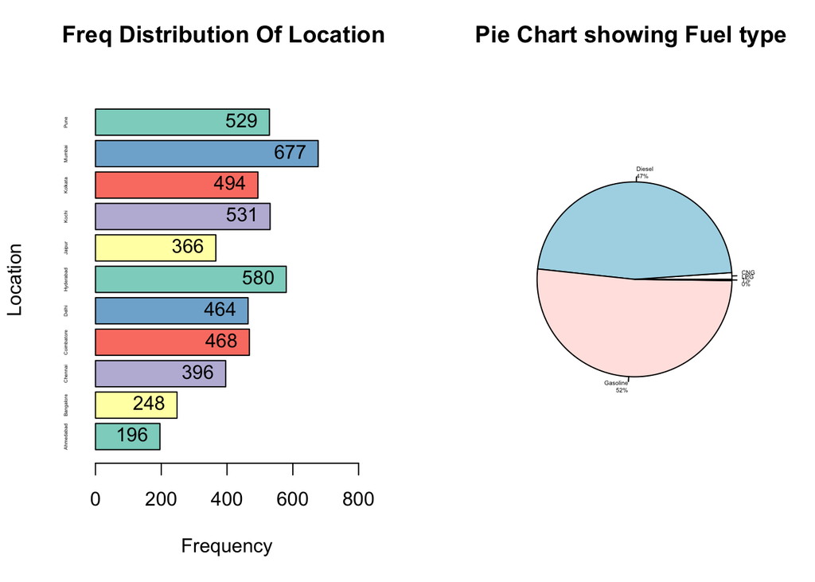

```r
#Task 2.1:
def_par <-par()
par(mfcol=c(1,2))

freq = table(M1data_carsales$Location)

bp1=barplot(freq, main="Freq Distribution Of Location \n", ylab = "Location", xlim = c(0, 800), xlab = "Frequency", col=brewer.pal(5,"Set3"), cex.names = 0.25, horiz = T)

text(freq,
     bp1,freq,
     cex=1,pos=2)

#Task 2.2:

Fuel_type = table(M1data_carsales$FuelType)

pctf <- round(Fuel_type/sum(Fuel_type)*100)
labl = paste(names(Fuel_type), "\n", pctf, sep="", "%")
pie(Fuel_type, labels = labl,
   main ="Pie Chart showing Fuel type \n", cex = 0.31)
```

**Task 3:** **Created table with representing Owner and its frequency and percentage distribution**

```r
#Task 3:
task3_table = M1data_carsales$Owner%>%
table() %>%
as.data.frame()%>%
rename(Frequency = Freq)%>%
mutate(Cumulative_Frequency = cumsum(Frequency),
Percentage = (Frequency/nrow(M1data_carsales))*100 ,
Cummulative_Percentage = cumsum(Percentage))

knitr::kable(task3_table,
digits = 2,
caption = "Frequency of Owners of Cars",
format = "html",
table.attr = "style='width:30%;'",
align = 'c')  %>%

kable_classic(bootstrap_options = "hover",
full_width = TRUE,
position= "center",
font_size = 13,
lightable_options = "basic",
  html_font = "\"Arial Narrow\", \"Source Sans Pro\", sans-serif",
)
```

Frequency of Owners of Cars

| . | Frequency | Cumulative_Frequency | Percentage | Cummulative_Percentage |
| --- | --- | --- | --- | --- |
| First | 2921 | 2921 | 59.02 | 59.02 |
| Fourth | 782 | 3703 | 15.80 | 74.82 |
| Second | 916 | 4619 | 18.51 | 93.33 |
| Third | 330 | 4949 | 6.67 | 100.00 |

**Observation**  
In the frequency distribution for Owners of cars, we can see that most of the dataset have first hand cars i.e. they only had one owner i.e. (2921). The thing to observe in the table is that frequency of cars who had 3 owners are less than four times owned cars.

**Task 4:** **Using density() and plot() functions and presenting a density curve for kilometer variable. Also represented vertical lines for points based on z scores**

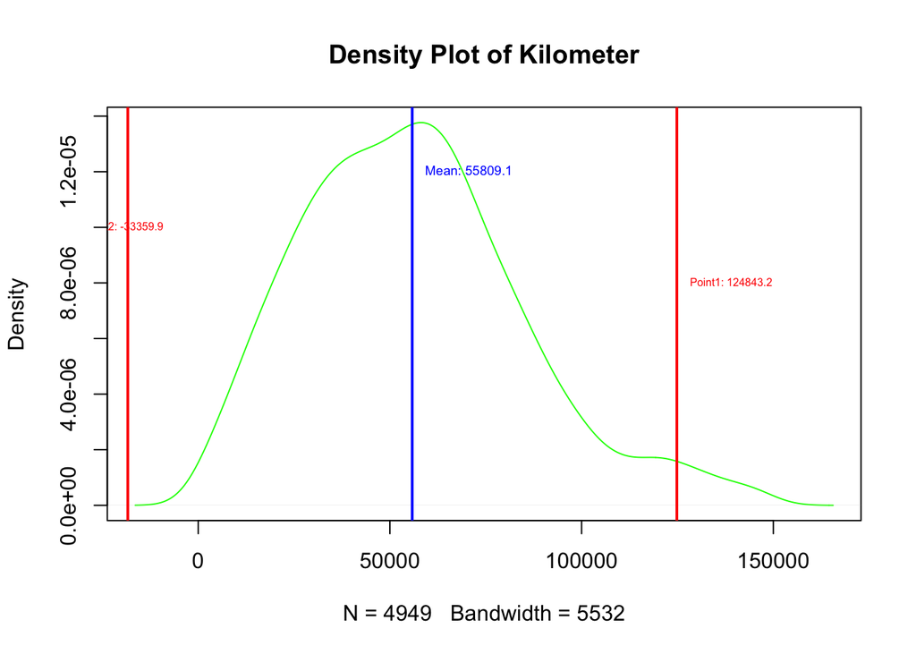

```r
#Task 4:
density(M1data_carsales$Km, adjust = 1.2) %>%
plot(col="green", main="Density Plot of Kilometer")

abline(v = mean(M1data_carsales$Km),
       col = "blue",
       lwd = 2)

text(x=mean(M1data_carsales$Km),
     y = 0.000012,
     paste("Mean:", round(mean(M1data_carsales$Km),1)),
     col = "blue",
     cex = 0.6,
     pos = 4)

#Plotting for Z scores

zscore_1 = 2.4
value1 = (zscore_1*sd(M1data_carsales$Km))  + mean(M1data_carsales$Km)

zscore_2 =-3.1
value2 = (zscore_2*sd(M1data_carsales$Km))  + mean(M1data_carsales$Km)


abline(v = value1,
       col = "red",
       lwd = 2)

text(x=value1 ,
     y = 0.000008,
     paste("Point1:", round(value1,1)),
     col = "red",
     cex = 0.5,
     pos = 4)

abline(v = value2+15000,
       col = "red",
       lwd = 2)

text(x=value2 ,
     y = 0.000010,
     paste("Point2:", round(value2,1)),
     col = "red",
     cex = 0.5,
     pos = 4)
```

**Observation**  
In the above density distribution for variable km, we can infer that mean is equal to 55809.1, the point1 above the mean is equal to 124843.2 whereas the point2 below the mean is -33359.9. In order to show the point 2 on density plot using abline function, I have used point2 + 15000 as the value in point2 was extremely small.

**Task 5:** **Showing a horizontal box plot and a histogram to display the variable kilometers distribution.**

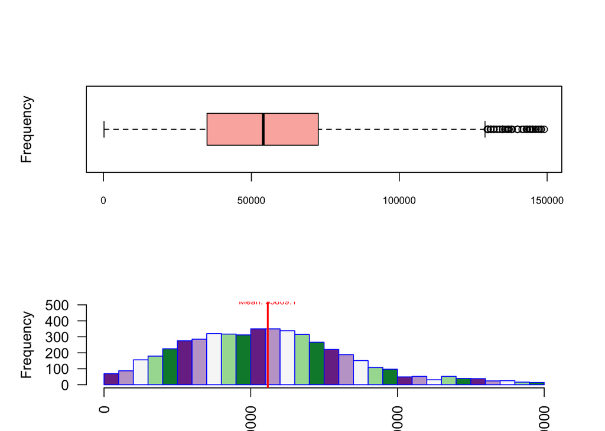

```r
#Task 5

par(mfrow = c(2,1), mai=c(0.5,1,1,0.5))

boxplot(M1data_carsales$Km,
        col = brewer.pal(3,"Pastel1"),
        main=NA,
        xlab= "Km",
        ylab= "Frequency",
        cex.name=0.7,
        cex.axis=0.7,
        las=1, horizontal = T
        )

hist(M1data_carsales$Km,
     main=NA,
     xlab="Km",
     border="blue",
     col= brewer.pal(5,name="PRGn"),
          ylim=c(0,500),
     xlim=c(0,150000),
     las=2,breaks=30)

abline(v = mean(M1data_carsales$Km), col = "red", lwd = 2)

text(x=mean(M1data_carsales$Km) ,
     y = 450,
     paste("Mean:", round(mean(M1data_carsales$Km),1)),
     col = "red",
     cex = 0.6,
     pos = 3)
```

**Observation**

**Task 6:** **presenting the box plot and histogram for price of Cars.**

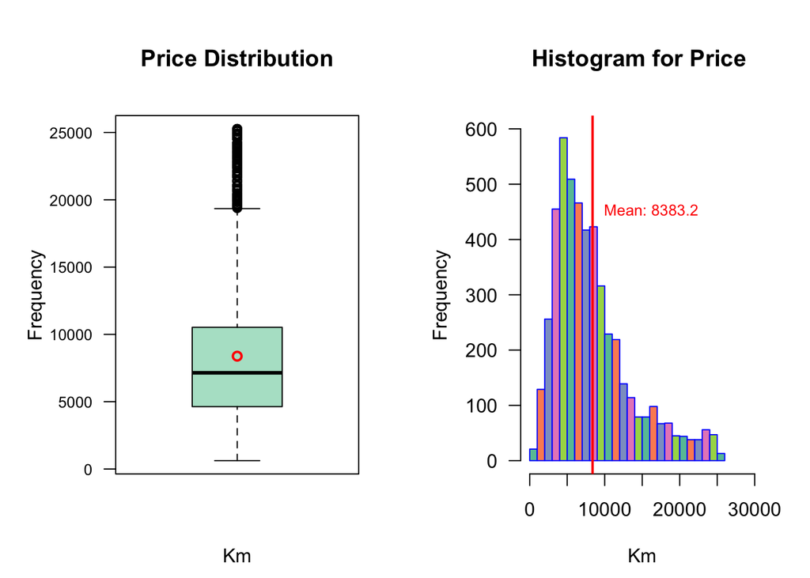

```r
#Task 6: Boxplot representation
par(mfcol = c(1,2), mai=c(0.9,1,1,0.4))

boxplot(M1data_carsales$Price,
        col = brewer.pal(3,"Pastel2"),
        main="Price Distribution",
        xlab= "Km",
        ylab= "Frequency",
        cex.name=0.8,
        cex.axis=0.8,
        las=1, horizontal = F
        )

points(mean(M1data_carsales$Price), col = "red", lwd = 2)

hist(M1data_carsales$Price,
     main="Histogram for Price ",
     xlab="Km",
     border="blue",
     col= brewer.pal(5,name="Set2"),
          ylim=c(0,600),
     xlim=c(0,30000),
     las=1,breaks=25)

abline(v = mean(M1data_carsales$Price), col = "red", lwd = 2)

text(x=mean(M1data_carsales$Price) ,
     y = 450,
     paste("Mean:", round(mean(M1data_carsales$Price),1)),
     col = "red",
     cex = 0.8,
     pos = 4)
```

**Task 7:** **Box plot displaying the price distribution per owner.**

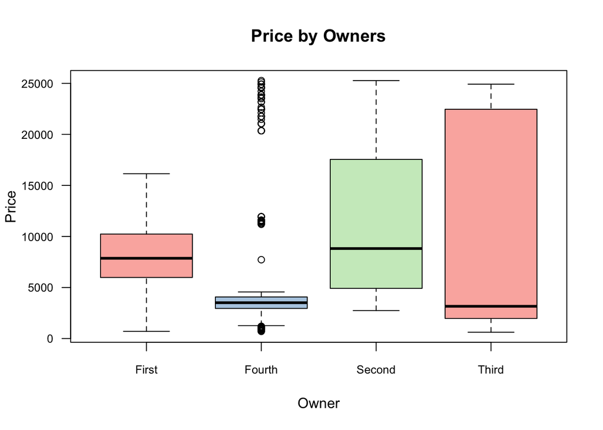

```r
#Task 7:

boxplot(M1data_carsales$Price ~ M1data_carsales$Owner,
        col = brewer.pal(3,"Pastel1"),
        main="Price by Owners",
        xlab= "Owner",
        ylab= "Price",
        cex.name=0.8,
        cex.axis=0.8,
        las=1
        )
```

**Task 8:** **Box plot displaying the Kilometer distribution in different Locations.**

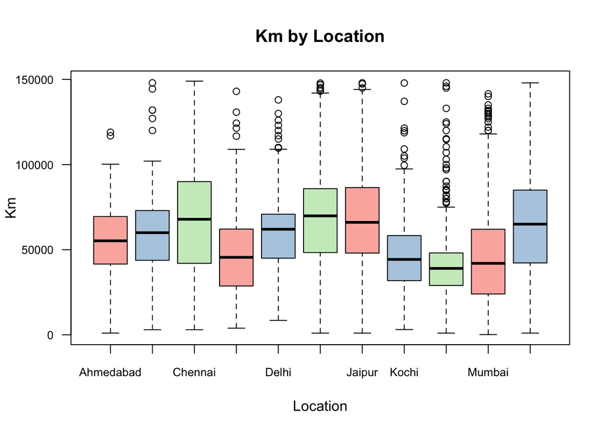

```r
#Task 8:
boxplot(M1data_carsales$Km ~ M1data_carsales$Location,
        col = brewer.pal(3,"Pastel1"),
        main="Km by Location",
        xlab= "Location",
        ylab= "Km",
        cex.name=0.2,
        cex.axis=0.8,
        las=1
        )
```

**Observation**  
According to the above chart, Chennai state seems to be having large scattered Km data points and has no outliers whereas rest of the cities seem to be having large number of outliers except Pune

**Task 9:** **Applying and presenting the outcomes of code boxplot.stats() for kilometer variable in the dataset.**

```r
boxplot.stats(M1data_carsales$Km)
```

```
## $stats
## [1]    171  34994  54000  72618 129000
##
## $n
## [1] 4949
##
## $conf
## [1] 53154.99 54845.01
##
## $out
##  [1] 137000 140000 137008 130000 145000 147898 135670 130000 145277 143143
## [11] 140000 129986 135000 138000 140000 138000 135000 130000 143000 148000
## [21] 140000 136642 143275 137148 135000 146000 131000 144400 143354 130790
## [31] 140000 132000 129750 130000 146000 130000 146824 144000 130002 148000
## [41] 130000 130000 130000 131000 130000 140000 140000 130000 135000 145000
## [51] 141537 134000 138000 130923 131000 132000 142000 149000 135000 130000
## [61] 130000 143017 132000 136000 136997 137000 133000 133000 133944 137800
## [71] 138000 148000 135000 132000 140000 146300 148009 144113 136000 135000
## [81] 138205 131765 131000 145000 147350 142000 147848 147000 140000 136490
## [91] 144471 135000 144000 130000
```

**Observation**  
The statistics are presented in a clear manner using stats() function, they also aid in distilling the data into significant numbers. Therefore, statistical techniques provide insightful data. In other words, statistics aid in making complex data simple and comprehensible. In the above output, stats represents a 5-dimensional vector made up of the median, the top ‘hinge,’ the extreme of the upper whisker, the lower ‘hinge,’ and the extreme of the lower whisker, whereas n represents sample population. Conf stands for the lower and upper extremes of the ‘notch’ and out represents the outliers which are at extremes.

**Task 10:** **Displaying the quartiles values for kilometers**

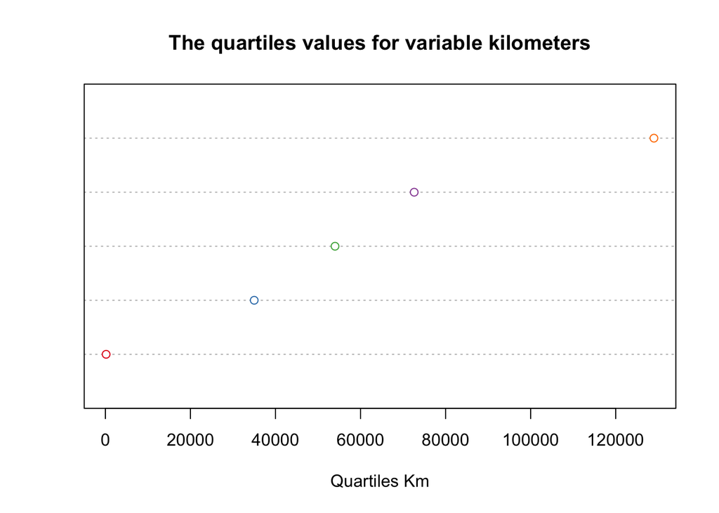

```r
#Task 10:

quartile_dot =boxplot.stats(M1data_carsales$Km)$stats

dotchart(quartile_dot,
         main="The quartiles values for variable kilometers",
         xlab = "Quartiles Km",
         col= brewer.pal(8,"Set1"))
```

**CONCLUSION**

- In India, most people like vehicles with a power output of 100 to 150 horsepower.
- Data from several years shows that people prefer five-seater cars in general.
- The majority of the data in kilometers ranges from 30 to 100K. The boxplot also shows that the data contains a lot of outliers.
- I learned a lot of R functions from this project. While working on the assignment, I discovered various different approaches to approach the same issue, such as using the pipe line symbols or the object creation to obtain the same results when calculating the observations of a variable.
- In this assignment, I have used the describe and select functions for the first time, which gives a better representation of the data.

I learned several R functions including describe, transform, and select as well as how to use them to improve reports while using the instructor’s scripts in a few of the projects. Being intermediate in R, I discovered that minor adjustments to the graph, such as axis length, axis names, and captions, can have a significant impact on the graph’s appearance.

> **BIBLIOGRAPHY**

References used:

1. Bluman, Allan G. Elementary Statistics: A Step by Step Approach. Tenth edition. New York, NY: McGraw-Hill Education, 2018.
2. Chiluiza, D. (2021, May 8). RPubs - Basic codes for R Markdown. RPubs. https://rpubs.com/Dee_Chiluiza/766786
3. Wagner, I. (2021, April 22). Automotive industry worldwide - statistics & facts. Statista. https://www.statista.com/topics/1487/automotive-industry/
4. RGB Color Codes Chart 🎨. (n.d.). Rapidtable. Retrieved June 5, 2021, from https://www.rapidtables.com/web/color/RGB_Color.html
5. Culver, M. (n.d.). Business Wire. Businesswire. Retrieved June 5, 2021, from https://www.businesswire.com/news/home/20201217005798/en/Global-Auto-Sales-Expected-to-Gain-Momentum-Next-Year-83.4-Million-Light-Vehicles-to-Be-Sold-In-2021-According-to-IHS-Markit
6. Thakkar, K., Shyam, A. R., Mukherjee, S., & Auto, E. T. (2021, January 11). Indian car market may post record 30% growth in 2021 on low base. ETAuto.Com. https://auto.economictimes.indiatimes.com/news/passenger-vehicle/cars/indian-car-market-may-post-record-30-growth-in-2021-on-low-base/80218106
7. *The R Graph Galley* https://r-graph-gallery.com/38-rcolorbrewers-palettes.html

> **APPENDIX**

An R Markdown file has been attached to this report. The name of the file is “Project1_SrishtiSingh”